# MiSBIE Exploratory Data Analysis

Christine Lucille Kuryla

2024-02-15

# Data Dictionary

## FILES FROM PHYSIOLOGICAL SIGNALS

File types  
_bp Blood Pressure Arterial blood pressure measured with finapress (finger) _rsp Respiration Respiratory rates and amplitudes measured with two chest bands (abdominal and thoracis) with signals averaged _rtimes Heart Rate Heart rate measured with 3-lead ECG, here each “r waves” is marked (all files manually checked), so the hear rate (beats per minutes) can be computed as the distance (in sec) between each wave divided by 60 (sec) .2.bi Bad Intervals Since the data sometimes contain noise or sections of the files with non-sinus rhythms that cannot be analyzed, there is a “bad interval” file for each period in the protocol in which such unanalyzable data occurred. These “BI” files are in text format and each line contains the start and stop time of each unscorable interval within each period. Analyses of data with bad intervals must exclude these portions of the files. _eda Electrodermal activity EDA or skin conductance measured every 1msec from the left palm. DATA TO COME FROM ELLIE YAN.

## VARIABLE DESCRIPTIONS

_bp Name Units pSec Time of systole seconds pVal Pressure at systole mmHg (milliliters of mercury) tSec Time of diatole seconds tVal Pressure at diastole mmHg (milliliters of mercury)

_rsp Name Units pSec Time of peak inspiration seconds pVal Value at peak inspiration mVolts (these should be in liters, will need to use calibration to convert) tSec Time of peak expiration seconds tVal Value at peak expiration mVolts (these should be in liters, will need to use calibration to convert)

_rtimes Name Units pSec Time of each r wave seconds

## Periods (in order) Description Duration

Base Baseline, after 25 minutes of resting. 366 seconds Pre First biological samples collected (saliva, blood, temp, affect) [-5min] 300 seconds Instruct Instructions for TSST given by study coordinator Variable duration (about 300 seconds) Prep Task Speech preparation, no pen or paper 122-123 seconds Task Public speech task (Trier social stress task - TSST) 183-184 seconds Post 5 Samples collected 5 minutes post-task 300 seconds Post 10 Samples collected 10 minutes post-task 300 seconds Post 20 Samples collected 20 minutes post-task 300 seconds Post 30 Samples collected 30 minutes post-task 300 seconds Post 60 Samples collected 60 minutes post-task 300 seconds Post 90 Samples collected 90 minutes post-task 300 seconds Post 120 Samples collected 120 minutes post-task 300 seconds DBT Deep Breathing Task: Paced breathing - inhalation/exhalation 420 seconds ST Sit Stand: Participants go from seated position to standing, remain standing 420 seconds SST Sit Stand Test: Participants repeatedly sit and stand (squats) for 30 secs 420 seconds CP Cold Pressor Task: Participants submerge one hand in ice bath for 90 secs 660 seconds

# Load and Explore Data

```r
data_hr <- read_csv("./data/data_from_email/hr_cleaned.csv")
data_bp <- read_csv("./data/data_from_email/bp_cleaned.csv")
data_rsp <- read_csv("./data/data_from_email/rsp_cleaned.csv")
data_pt_cond <- read_csv("./data/data_from_email/patient condition.csv")
length(unique(data_hr$id)) # 71
```

```
## [1] 71
```

```r
length(unique(data_rsp$id)) #53
```

```
## [1] 53
```

```r
length(unique(data_bp$id)) # 68
```

```
## [1] 68
```

```r
subj_hr <- unique(data_hr$id)
subj_rsp <- unique(data_rsp$id)
subj_bp <- unique(data_bp$id)

length(intersect(subj_hr, subj_bp))
```

```
## [1] 68
```

```r
length(intersect(subj_hr, subj_rsp))
```

```
## [1] 53
```

```r
length(intersect(subj_bp, subj_rsp))
```

```
## [1] 52
```

```r
length(intersect(intersect(subj_hr, subj_bp), subj_rsp))
```

```
## [1] 52
```

```r
# Heart Rate
colnames(data_hr)
```

```
## [1] "pSec"      "id"        "period"    "rate"      "time"      "condition"
```

```r
table(data_hr$period)
```

```
##
##           1          10          11          12           2           3
##       31418       24835       24639       24655       25488       24010
##           4           5           6           7           8           9
##       11109       17600       25558       25399       24700       25266
## Acquisition          C3          CP         DBT    Preptask         SST
##        2758         527       56016       36229         196       33167
##          ST
##       36374
```

```r
table(data_hr$id)
```

```
##
## mi001 mi002 mi003 mi004 mi005 mi006 mi007 mi008 mi009 mi010 mi011 mi012 mi013
##  6376  6328  6519  7605  5765  6378  7109  6924  5233  5152  8670  6479  9587
## mi014 mi015 mi016 mi017 mi018 mi019 mi020 mi021 mi022 mi023 mi024 mi025 mi026
## 10031  6569  5835  5753  7288  5634  7153  7727  6614  6512  6426  5708  5335
## mi027 mi028 mi029 mi030 mi031 mi032 mi033 mi034 mi035 mi036 mi037 mi038 mi039
##  6122  6512  6199  6621  1173  6343  5855  7045  8626  8655  6913  7272  6209
## mi040 mi041 mi042 mi043 mi044 mi045 mi046 mi047 mi048 mi049 mi050 mi051 mi052
##  6138  6920   376  6412  7535  9934  7087  5769  8080  6506  2774  6892  8029
## mi053 mi054 mi055 mi056 mi057 mi058 mi059 mi060 mi061 mi062 mi063 mi064 mi065
##  5869  7767  6951  6785  6796  6687  5344  6918  5609  6167  6449  6100  4843
## mi066 mi067 mi068 mi069 mi071 mi072
##  6185  6456  6153  6610  6676  2145
```

```r
table(data_hr$condition)
```

```
##
##  Control Deletion    MELAS Mutation
##   139074    58506    14969    73087
```

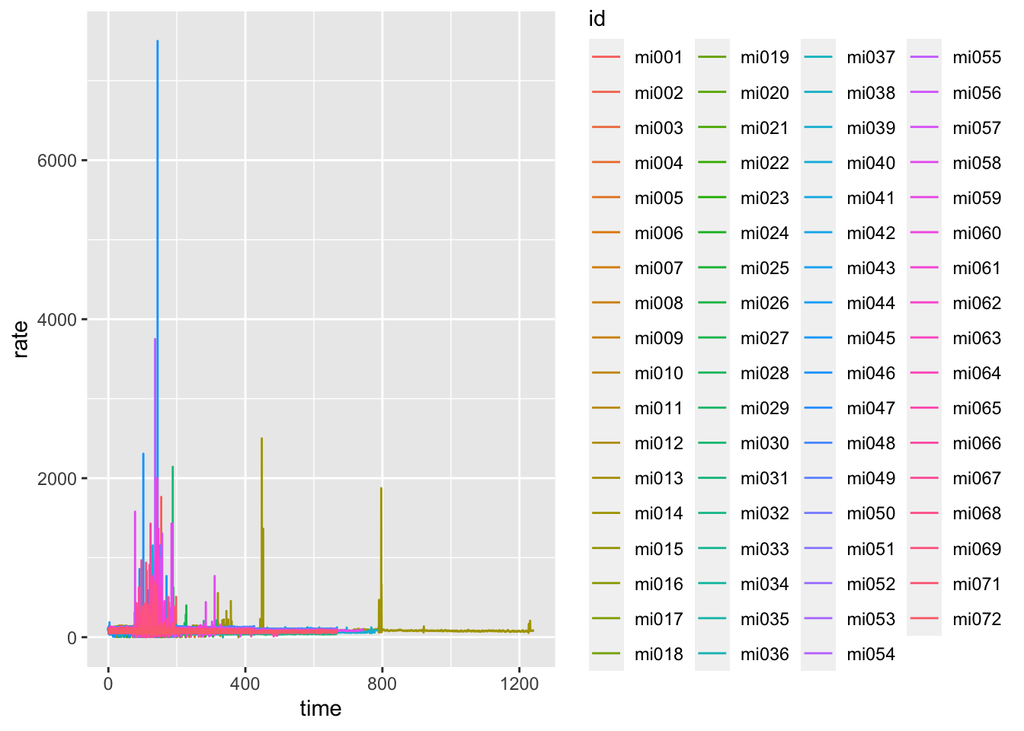

```r
data_hr %>%
  ggplot(aes(x = time, y = rate, color = id)) +
  geom_line()
```

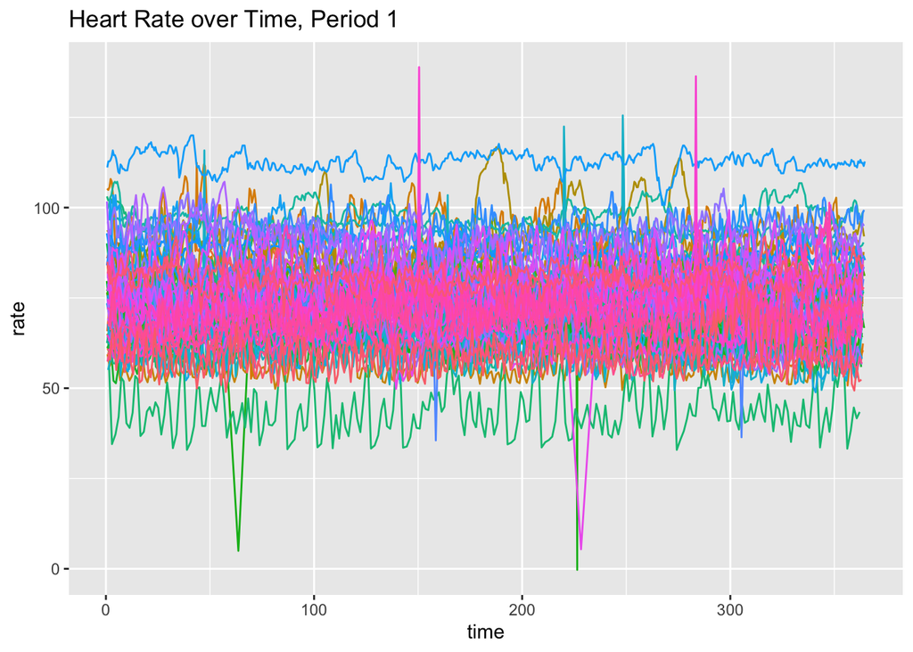

```r
data_hr %>%
  filter(rate < 1000) %>%
  filter(period == 1) %>%
  ggplot(aes(x = time, y = rate, color = id)) +
 # geom_point() +
  geom_line() +
  theme(legend.position = "none") +
  labs(title = "Heart Rate over Time, Period 1")
```